# Monoculture analysis

#libraries

#load data (change pathway here)

# Monoculture bacteria strain in 0 hr and 24 hr (OD1)

Compile data from different sheets to get population size at start (0 hr) and end (24 hr) points under OD = 1.

| strain | replicate | M0 | logM0 | M24 | logM24 |
| --- | --- | --- | --- | --- | --- |
| BIGb0170 | 1 | 5.00e+09 | 9.698970 | 6.00e+11 | 11.778151 |
| BIGb0170 | 2 | 4.80e+09 | 9.681241 | 6.40e+11 | 11.806180 |
| BIGb0170 | 3 | 6.10e+09 | 9.785330 | 7.60e+11 | 11.880814 |
| BIGb0172 | 1 | 4.80e+09 | 9.681241 | 3.60e+11 | 11.556303 |
| BIGb0172 | 2 | 4.00e+09 | 9.602060 | 2.80e+11 | 11.447158 |
| BIGb0172 | 3 | 4.10e+09 | 9.612784 | 4.00e+11 | 11.602060 |
| BIGb0393 | 1 | 9.90e+09 | 9.995635 | 4.72e+11 | 11.673942 |
| BIGb0393 | 2 | 4.40e+09 | 9.643453 | 2.64e+11 | 11.421604 |
| BIGb0393 | 3 | 8.90e+09 | 9.949390 | 3.48e+11 | 11.541579 |
| JUb19 | 1 | 1.66e+10 | 10.220108 | 3.00e+12 | 12.477121 |

[output cut: 29 more lines]

## OD0.1 and OD0.5 data reconstruction and binding to OD1 data

Based on May 7th Discussion, conducted monoculture growth assay at lower initial densities. Compile data from all OD values.

| strain | replicate | OD | M0 | M24 | M12 | logM0 | logM24 | logM12 |
| --- | --- | --- | --- | --- | --- | --- | --- | --- |
| BIGb0170 | 1 | 0.1 | 9.40e+08 | 1.76e+12 | NA | 8.973128 | 12.245513 | NA |
| BIGb0170 | 2 | 0.1 | 9.30e+08 | 1.24e+12 | NA | 8.968483 | 12.093422 | NA |
| BIGb0170 | 3 | 0.1 | 9.00e+08 | 9.60e+11 | NA | 8.954243 | 11.982271 | NA |
| BIGb0170 | 1 | 0.5 | 8.50e+09 | 3.56e+12 | 1.52e+11 | 9.929419 | 12.551450 | 11.181844 |
| BIGb0170 | 2 | 0.5 | 7.80e+09 | 2.76e+12 | 1.20e+11 | 9.892095 | 12.440909 | 11.079181 |
| BIGb0170 | 3 | 0.5 | 7.80e+09 | 3.28e+12 | 6.00e+10 | 9.892095 | 12.515874 | 10.778151 |
| BIGb0172 | 1 | 0.1 | 2.40e+08 | 1.88e+11 | NA | 8.380211 | 11.274158 | NA |
| BIGb0172 | 2 | 0.1 | 1.60e+08 | 1.52e+11 | NA | 8.204120 | 11.181844 | NA |
| BIGb0172 | 3 | 0.1 | 2.60e+08 | 1.60e+11 | NA | 8.414973 | 11.204120 | NA |
| BIGb0172 | 1 | 0.5 | 4.60e+08 | 2.80e+11 | 5.56e+09 | 8.662758 | 11.447158 | 9.745075 |

[output cut: 98 more lines]

# Monogrowth line in different OD level

For each microbe, we show the population size change over 24 hours. Colors represent different starting OD values.

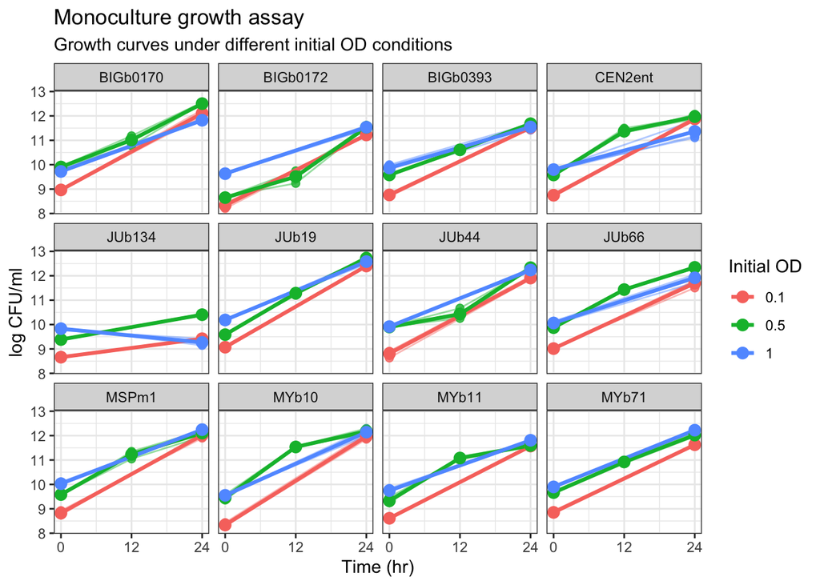

## $\alpha_{ii}$ and $r_i$ from monoculture (statistical fitting)

Consider a Lotkta–Volterra competition model in the form of $\frac{dN_i}{dt} = N_i(r_i-\alpha_{ii}N_i-\alpha_{ij}N_j)$. Here, we combined all monoculture growth assay data from different initial OD values to perform a linear regression (all density data were scaled by $10^9$ prior to calculation). The response variable is $\frac{\Delta lnN_i}{\Delta t}$, which is an estimate of the species per capita growth rate, and the dependent variable is the initial density at 0 hr. This allowed us to estimate each species’ intraspecific competition: the y-intercept represents the species’ intrinsic growth rate ($r_i$) and the slope represents the strength of intraspecific competition ($\alpha_{ii}$). We were able to employ this statistical approach because the different OD dataset spans a large-enough range of initial values. Below, we show: (1) a depiction of the statistial fit, (2) species’ estimated intraspecific competition strength $\alpha_{ii}$, and (3) species’ estimated intrinsic growth rate $r_i$. Microbe JUb19 is a species with high intrinsic growth rate and weak self-limitation.

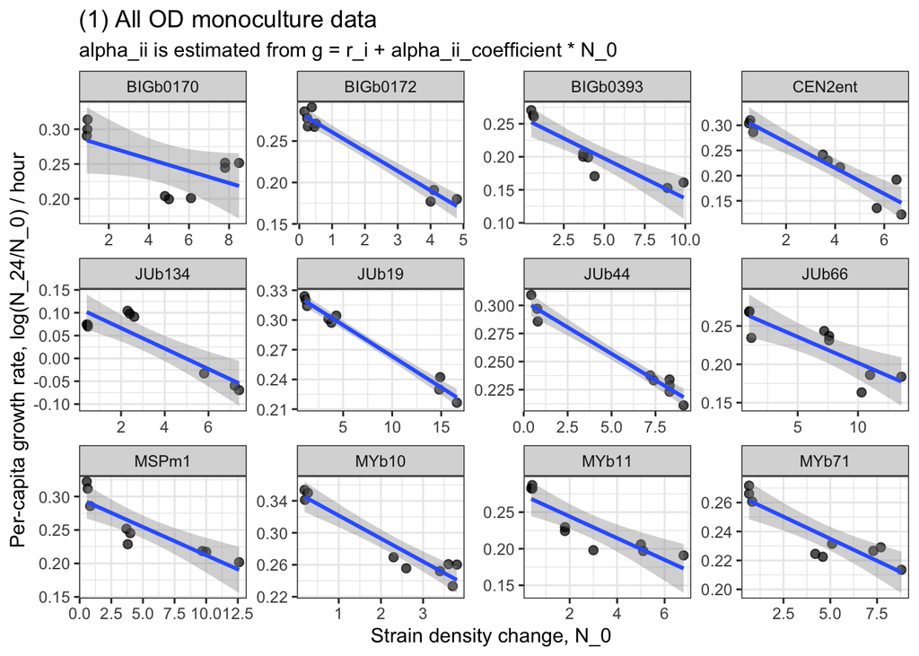

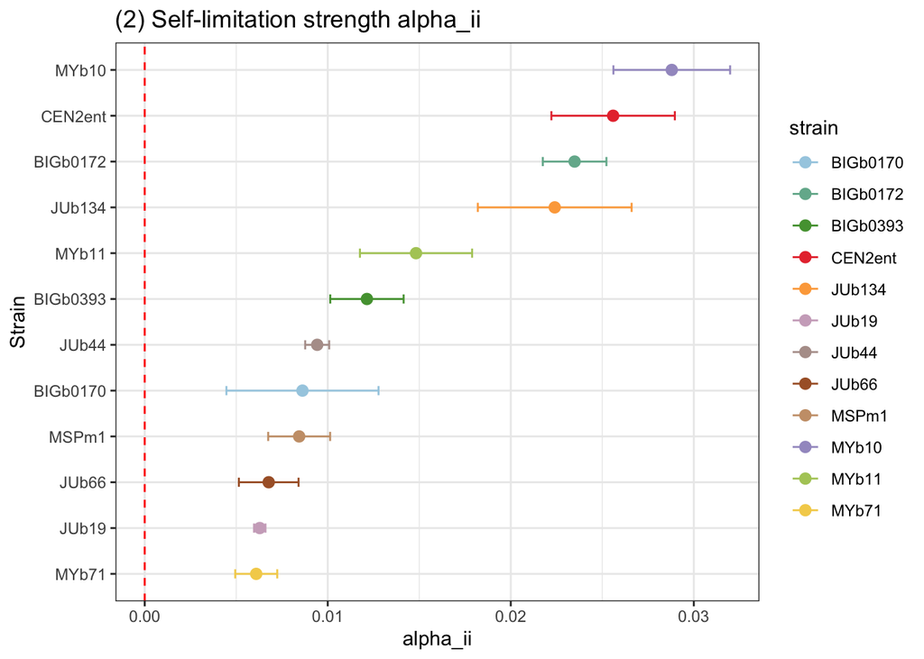

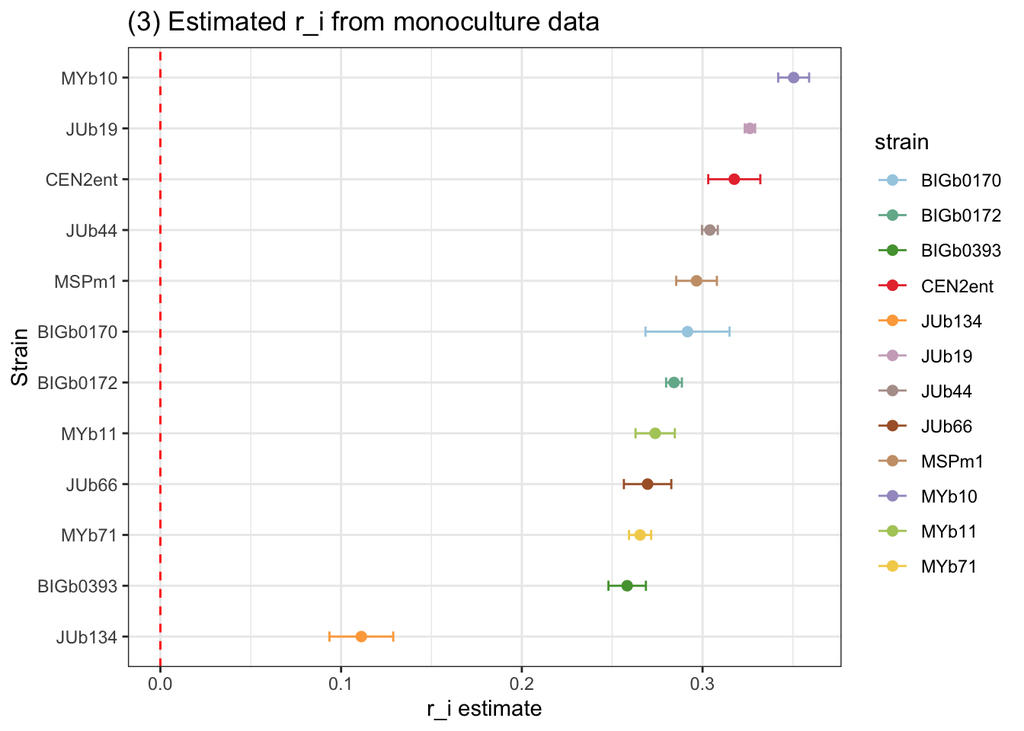